# Uso de la API del Covid19 con Pandas

Esta práctica está realizada con **Python 3**, un lenguaje de programación cuya importancia radica en que la sintaxis dé como resultado un **código legible** y de **fácil comprensión**. Python 3 se define según esta [fuente](https://plataforma.josedomingo.org/pledin/cursos/python3/#:~:text=Python%20es%20un%20lenguaje%20de,en%20menor%20medida%2C%20programaci%C3%B3n%20funcional). como: "un lenguaje de **programación multiparadigma**, ya que soporta orientación a objetos, programación imperativa y, en menor medida, programación funcional".

La URL: https://api.covid19api.com/countries

## Instalación librerías

```python
!pip install pandas
```

## Configuración de Pandas

```python
import pandas as pd
```

## Crear variable

```python
url = 'https://api.covid19api.com/countries'
```

## Crear Dataframe

```python
df = pd.read_json(url)
```

La función "read_jason" lee un JSON, y dentro del paréntesis la función de lo que queremos que lea, en este caso un url. Es decir, si yo voy con esta función al navegador lo que me devuelve es un JSON, una lista de diccionarios. Al crear un Dataframe creamos una tabla que nos lee esto en JSON

```python
df
```

|  | Country | Slug | ISO2 |
| --- | --- | --- | --- |
| 0 | French Polynesia | french-polynesia | PF |
| 1 | Indonesia | indonesia | ID |
| 2 | Malta | malta | MT |
| 3 | Sao Tome and Principe | sao-tome-and-principe | ST |
| 4 | Haiti | haiti | HT |
| ... | ... | ... | ... |
| 243 | Myanmar | myanmar | MM |
| 244 | Turkey | turkey | TR |
| 245 | Western Sahara | western-sahara | EH |
| 246 | Pitcairn | pitcairn | PN |
| 247 | Tanzania, United Republic of | tanzania | TZ |

248 rows × 3 columns

## Exploración de la tabla

```python
df.head()
```

|  | Country | Slug | ISO2 |
| --- | --- | --- | --- |
| 0 | French Polynesia | french-polynesia | PF |
| 1 | Indonesia | indonesia | ID |
| 2 | Malta | malta | MT |
| 3 | Sao Tome and Principe | sao-tome-and-principe | ST |
| 4 | Haiti | haiti | HT |

Al Dataframe (df) le ponemos el **.** para aplicarle la función **head**. El paréntesis vacío hace que te muestre solo la cabecera, si queremos un número de paises concretos se pone (número). Con **.tail** pasa igual

```python
df.tail(2)
```

|  | Country | Slug | ISO2 |
| --- | --- | --- | --- |
| 246 | Pitcairn | pitcairn | PN |
| 247 | Tanzania, United Republic of | tanzania | TZ |

```python
df.info()
```

```
<class 'pandas.core.frame.DataFrame'>
RangeIndex: 248 entries, 0 to 247
Data columns (total 3 columns):
 #   Column   Non-Null Count  Dtype
---  ------   --------------  -----
 0   Country  248 non-null    object
 1   Slug     248 non-null    object
 2   ISO2     248 non-null    object
dtypes: object(3)
memory usage: 5.9+ KB
```

La función **.info** nos explica qué hay en el dataframe

```python
df['Country']
```

```
0                  French Polynesia
1                         Indonesia
2                             Malta
3             Sao Tome and Principe
4                             Haiti
                   ...
243                         Myanmar
244                          Turkey
245                  Western Sahara
246                        Pitcairn
247    Tanzania, United Republic of
Name: Country, Length: 248, dtype: object
```

```python
df['Country'] [66]
```

```
'Somalia'
```

Para centrarnos en una columna concreta ponermos los **[ ]** y dentro entre comillas simples **''** el nombre de la columna tal cual viene. Para coger un número concreto de la lista abrimos otros corchetes y ponemos el número dentro

## Tiempo real

https://api.covid19api.com/country/spain/status/confirmed/live

Con esto estamos creando un Dataframe con una url solo de datos de España

```python
url_es = 'https://api.covid19api.com/country/spain/status/confirmed/live'
```

```python
df_es = pd.read_json(url_es)
```

```python
df_es
```

|  | Country | CountryCode | Province | City | CityCode | Lat | Lon | Cases | Status | Date |
| --- | --- | --- | --- | --- | --- | --- | --- | --- | --- | --- |
| 0 | Spain | ES |  |  |  | 40.46 | -3.75 | 0 | confirmed | 2020-01-22 00:00:00+00:00 |
| 1 | Spain | ES |  |  |  | 40.46 | -3.75 | 0 | confirmed | 2020-01-23 00:00:00+00:00 |
| 2 | Spain | ES |  |  |  | 40.46 | -3.75 | 0 | confirmed | 2020-01-24 00:00:00+00:00 |
| 3 | Spain | ES |  |  |  | 40.46 | -3.75 | 0 | confirmed | 2020-01-25 00:00:00+00:00 |
| 4 | Spain | ES |  |  |  | 40.46 | -3.75 | 0 | confirmed | 2020-01-26 00:00:00+00:00 |
| ... | ... | ... | ... | ... | ... | ... | ... | ... | ... | ... |
| 798 | Spain | ES |  |  |  | 40.46 | -3.75 | 11508309 | confirmed | 2022-03-30 00:00:00+00:00 |
| 799 | Spain | ES |  |  |  | 40.46 | -3.75 | 11508309 | confirmed | 2022-03-31 00:00:00+00:00 |
| 800 | Spain | ES |  |  |  | 40.46 | -3.75 | 11551574 | confirmed | 2022-04-01 00:00:00+00:00 |
| 801 | Spain | ES |  |  |  | 40.46 | -3.75 | 11551574 | confirmed | 2022-04-02 00:00:00+00:00 |
| 802 | Spain | ES |  |  |  | 40.46 | -3.75 | 11551574 | confirmed | 2022-04-03 00:00:00+00:00 |

803 rows × 10 columns

```python
df_es.columns
```

```
Index(['Country', 'CountryCode', 'Province', 'City', 'CityCode', 'Lat', 'Lon',
       'Cases', 'Status', 'Date'],
      dtype='object')
```

La función **.columns** dice el nombre de las distintas columnas que hay

```python
df_es['Date'].head(1)
```

```
0   2020-01-22 00:00:00+00:00
Name: Date, dtype: datetime64[ns, UTC]
```

```python
df_es.info()
```

```
<class 'pandas.core.frame.DataFrame'>
RangeIndex: 803 entries, 0 to 802
Data columns (total 10 columns):
 #   Column       Non-Null Count  Dtype
---  ------       --------------  -----
 0   Country      803 non-null    object
 1   CountryCode  803 non-null    object
 2   Province     803 non-null    object
 3   City         803 non-null    object
 4   CityCode     803 non-null    object
 5   Lat          803 non-null    float64
 6   Lon          803 non-null    float64
 7   Cases        803 non-null    int64
 8   Status       803 non-null    object
 9   Date         803 non-null    datetime64[ns, UTC]
dtypes: datetime64[ns, UTC](1), float64(2), int64(1), object(6)
memory usage: 62.9+ KB
```

```python
df_es.describe()
```

|  | Lat | Lon | Cases |
| --- | --- | --- | --- |
| count | 8.030000e+02 | 803.00 | 8.030000e+02 |
| mean | 4.046000e+01 | -3.75 | 3.242248e+06 |
| std | 7.109856e-15 | 0.00 | 3.109442e+06 |
| min | 4.046000e+01 | -3.75 | 0.000000e+00 |
| 25% | 4.046000e+01 | -3.75 | 3.186710e+05 |
| 50% | 4.046000e+01 | -3.75 | 3.149012e+06 |
| 75% | 4.046000e+01 | -3.75 | 4.920388e+06 |
| max | 4.046000e+01 | -3.75 | 1.155157e+07 |

La función **.describe** se centra en los valores numéricos. Hace un conteo de los valores, al media, la mínima, la desviación típica...

```python
df_es
```

|  | Country | CountryCode | Province | City | CityCode | Lat | Lon | Cases | Status | Date |
| --- | --- | --- | --- | --- | --- | --- | --- | --- | --- | --- |
| 0 | Spain | ES |  |  |  | 40.46 | -3.75 | 0 | confirmed | 2020-01-22 00:00:00+00:00 |
| 1 | Spain | ES |  |  |  | 40.46 | -3.75 | 0 | confirmed | 2020-01-23 00:00:00+00:00 |
| 2 | Spain | ES |  |  |  | 40.46 | -3.75 | 0 | confirmed | 2020-01-24 00:00:00+00:00 |
| 3 | Spain | ES |  |  |  | 40.46 | -3.75 | 0 | confirmed | 2020-01-25 00:00:00+00:00 |
| 4 | Spain | ES |  |  |  | 40.46 | -3.75 | 0 | confirmed | 2020-01-26 00:00:00+00:00 |
| ... | ... | ... | ... | ... | ... | ... | ... | ... | ... | ... |
| 798 | Spain | ES |  |  |  | 40.46 | -3.75 | 11508309 | confirmed | 2022-03-30 00:00:00+00:00 |
| 799 | Spain | ES |  |  |  | 40.46 | -3.75 | 11508309 | confirmed | 2022-03-31 00:00:00+00:00 |
| 800 | Spain | ES |  |  |  | 40.46 | -3.75 | 11551574 | confirmed | 2022-04-01 00:00:00+00:00 |
| 801 | Spain | ES |  |  |  | 40.46 | -3.75 | 11551574 | confirmed | 2022-04-02 00:00:00+00:00 |
| 802 | Spain | ES |  |  |  | 40.46 | -3.75 | 11551574 | confirmed | 2022-04-03 00:00:00+00:00 |

803 rows × 10 columns

El valor de la **gráfica** (lo que hay que hacer) es el *número de casos*, que está en el **eje Y**, y las *fechas* irían en el **eje X**

```python
df_es.set_index('Date')
```

| Date | Country | CountryCode | Province | City | CityCode | Lat | Lon | Cases | Status |
| --- | --- | --- | --- | --- | --- | --- | --- | --- | --- |
| 2020-01-22 00:00:00+00:00 | Spain | ES |  |  |  | 40.46 | -3.75 | 0 | confirmed |
| 2020-01-23 00:00:00+00:00 | Spain | ES |  |  |  | 40.46 | -3.75 | 0 | confirmed |
| 2020-01-24 00:00:00+00:00 | Spain | ES |  |  |  | 40.46 | -3.75 | 0 | confirmed |
| 2020-01-25 00:00:00+00:00 | Spain | ES |  |  |  | 40.46 | -3.75 | 0 | confirmed |
| 2020-01-26 00:00:00+00:00 | Spain | ES |  |  |  | 40.46 | -3.75 | 0 | confirmed |
| ... | ... | ... | ... | ... | ... | ... | ... | ... | ... |
| 2022-03-30 00:00:00+00:00 | Spain | ES |  |  |  | 40.46 | -3.75 | 11508309 | confirmed |
| 2022-03-31 00:00:00+00:00 | Spain | ES |  |  |  | 40.46 | -3.75 | 11508309 | confirmed |
| 2022-04-01 00:00:00+00:00 | Spain | ES |  |  |  | 40.46 | -3.75 | 11551574 | confirmed |
| 2022-04-02 00:00:00+00:00 | Spain | ES |  |  |  | 40.46 | -3.75 | 11551574 | confirmed |
| 2022-04-03 00:00:00+00:00 | Spain | ES |  |  |  | 40.46 | -3.75 | 11551574 | confirmed |

803 rows × 9 columns

La función **.set_index** pone la columna Dates, que es la que hemos marcado, la primera. Como la otra columna que queremos en la de casos confirmados, el resto sobra, añadimos en **[ ]** el nombre de la otra columna y hacemos lo siguiente:

```python
df_es.set_index('Date')['Cases']
```

```
Date
2020-01-22 00:00:00+00:00           0
2020-01-23 00:00:00+00:00           0
2020-01-24 00:00:00+00:00           0
2020-01-25 00:00:00+00:00           0
2020-01-26 00:00:00+00:00           0
                               ...
2022-03-30 00:00:00+00:00    11508309
2022-03-31 00:00:00+00:00    11508309
2022-04-01 00:00:00+00:00    11551574
2022-04-02 00:00:00+00:00    11551574
2022-04-03 00:00:00+00:00    11551574
Name: Cases, Length: 803, dtype: int64
```

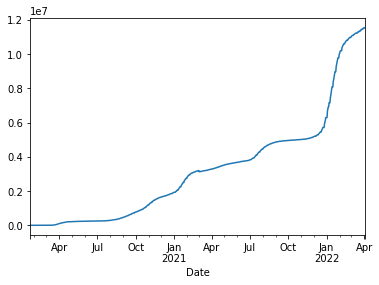

```python
df_es.set_index('Date')['Cases'].plot()
```

La función **.plot()** (una de las funciones de Python por defecto, sirve para pintar la gráfica

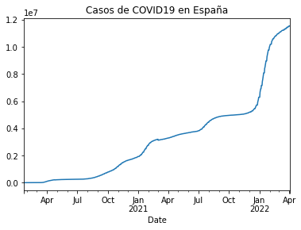

```python
df_es.set_index('Date')['Cases'].plot(title="Casos de COVID19 en España")
```

La función **.plot(title="título gráfica")** sirve para poner título a la gráfica

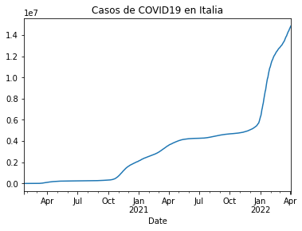

```python
url_it = 'https://api.covid19api.com/country/italy/status/confirmed/live'
df_it = pd.read_json(url_it)
df_it.set_index('Date')['Cases'].plot(title="Casos de COVID19 en Italia")
```

Una vez seguido todo el procedimiento podemos usar los tres códigos empleados arriba para conocer la gráfica de otros países

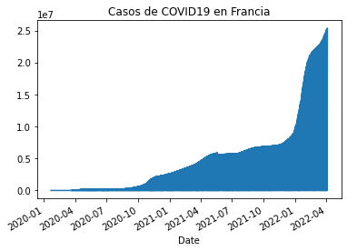

```python
url_fr = 'https://api.covid19api.com/country/france/status/confirmed/live'
df_fr = pd.read_json(url_fr)
df_fr.set_index('Date')['Cases'].plot(title="Casos de COVID19 en Francia")
```

## Comparación

```python
casos_es = df_es.set_index('Date')['Cases']
casos_it = df_it.set_index('Date')['Cases']
```

```python
pd.concat([casos_es,casos_it],axis=1)
```

| Date | Cases | Cases |
| --- | --- | --- |
| 2020-01-22 00:00:00+00:00 | 0 | 0 |
| 2020-01-23 00:00:00+00:00 | 0 | 0 |
| 2020-01-24 00:00:00+00:00 | 0 | 0 |
| 2020-01-25 00:00:00+00:00 | 0 | 0 |
| 2020-01-26 00:00:00+00:00 | 0 | 0 |
| ... | ... | ... |
| 2022-03-30 00:00:00+00:00 | 11508309 | 14567990 |
| 2022-03-31 00:00:00+00:00 | 11508309 | 14642354 |
| 2022-04-01 00:00:00+00:00 | 11551574 | 14719394 |
| 2022-04-02 00:00:00+00:00 | 11551574 | 14790806 |
| 2022-04-03 00:00:00+00:00 | 11551574 | 14845815 |

803 rows × 2 columns

Vamos a usar la función **.concat** para crear una serie con ambos países y poder compararlo

```python
vs = pd.concat([casos_es,casos_it],axis=1)
vs
```

| Date | Cases | Cases |
| --- | --- | --- |
| 2020-01-22 00:00:00+00:00 | 0 | 0 |
| 2020-01-23 00:00:00+00:00 | 0 | 0 |
| 2020-01-24 00:00:00+00:00 | 0 | 0 |
| 2020-01-25 00:00:00+00:00 | 0 | 0 |
| 2020-01-26 00:00:00+00:00 | 0 | 0 |
| ... | ... | ... |
| 2022-03-30 00:00:00+00:00 | 11508309 | 14567990 |
| 2022-03-31 00:00:00+00:00 | 11508309 | 14642354 |
| 2022-04-01 00:00:00+00:00 | 11551574 | 14719394 |
| 2022-04-02 00:00:00+00:00 | 11551574 | 14790806 |
| 2022-04-03 00:00:00+00:00 | 11551574 | 14845815 |

803 rows × 2 columns

Con esto estamos llamando a toda esa línea **"vs"** para reducir el número de caracteres en pantalla, por eso si ponemos vs solo sale todo

```python
vs.columns = ['España', 'Italia']
```

```python
vs.columns
```

```
Index(['España', 'Italia'], dtype='object')
```

```python
vs
```

| Date | España | Italia |
| --- | --- | --- |
| 2020-01-22 00:00:00+00:00 | 0 | 0 |
| 2020-01-23 00:00:00+00:00 | 0 | 0 |
| 2020-01-24 00:00:00+00:00 | 0 | 0 |
| 2020-01-25 00:00:00+00:00 | 0 | 0 |
| 2020-01-26 00:00:00+00:00 | 0 | 0 |
| ... | ... | ... |
| 2022-03-30 00:00:00+00:00 | 11508309 | 14567990 |
| 2022-03-31 00:00:00+00:00 | 11508309 | 14642354 |
| 2022-04-01 00:00:00+00:00 | 11551574 | 14719394 |
| 2022-04-02 00:00:00+00:00 | 11551574 | 14790806 |
| 2022-04-03 00:00:00+00:00 | 11551574 | 14845815 |

803 rows × 2 columns

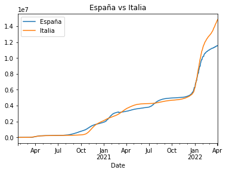

```python
vs.plot(title= "España vs Italia")
```

Repetimos el proceso con las funciones vistas más arriba para pintar la gráfica

# Comparación de los tres países

```python
casos_es = df_es.set_index('Date')['Cases']
casos_it = df_it.set_index('Date')['Cases']
casos_fr = df_fr.set_index('Date')['Cases']
```

```python
pd.concat([casos_es,casos_it,casos_fr],axis=1)
```

| Date | Cases | Cases | Cases |
| --- | --- | --- | --- |
| 2020-01-22 00:00:00+00:00 | 0.0 | 0.0 | 0 |
| 2020-01-22 00:00:00+00:00 | 0.0 | 0.0 | 0 |
| 2020-01-22 00:00:00+00:00 | 0.0 | 0.0 | 0 |
| 2020-01-22 00:00:00+00:00 | 0.0 | 0.0 | 0 |
| 2020-01-22 00:00:00+00:00 | 0.0 | 0.0 | 0 |
| ... | ... | ... | ... |
| 2022-04-03 00:00:00+00:00 | 11551574.0 | 14845815.0 | 60413 |
| 2022-04-03 00:00:00+00:00 | 11551574.0 | 14845815.0 | 36891 |
| 2022-04-03 00:00:00+00:00 | 11551574.0 | 14845815.0 | 135981 |
| 2022-04-03 00:00:00+00:00 | 11551574.0 | 14845815.0 | 72318 |
| 2022-04-04 00:00:00+00:00 | NaN | NaN | 25302925 |

9637 rows × 3 columns

```python
vs = pd.concat([casos_es,casos_it,casos_fr],axis=1)
vs
```

| Date | Cases | Cases | Cases |
| --- | --- | --- | --- |
| 2020-01-22 00:00:00+00:00 | 0.0 | 0.0 | 0 |
| 2020-01-22 00:00:00+00:00 | 0.0 | 0.0 | 0 |
| 2020-01-22 00:00:00+00:00 | 0.0 | 0.0 | 0 |
| 2020-01-22 00:00:00+00:00 | 0.0 | 0.0 | 0 |
| 2020-01-22 00:00:00+00:00 | 0.0 | 0.0 | 0 |
| ... | ... | ... | ... |
| 2022-04-03 00:00:00+00:00 | 11551574.0 | 14845815.0 | 60413 |
| 2022-04-03 00:00:00+00:00 | 11551574.0 | 14845815.0 | 36891 |
| 2022-04-03 00:00:00+00:00 | 11551574.0 | 14845815.0 | 135981 |
| 2022-04-03 00:00:00+00:00 | 11551574.0 | 14845815.0 | 72318 |
| 2022-04-04 00:00:00+00:00 | NaN | NaN | 25302925 |

9637 rows × 3 columns

```python
vs.columns = ['España', 'Italia','Francia']
```

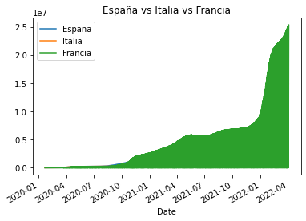

```python
vs.plot(title= "España vs Italia vs Francia")
```

```python
vs.to_csv('esvsit.csv')
```

```python
ls
```

```
 esvsit.csv                        'Prueba 2 (R).ipynb'   Shared_Resources@
 phython-api-covid19-pandas.ipynb   Prueba.ipynb          Untitled.ipynb
```

```python
!ls
```

```
 esvsit.csv			   'Prueba 2 (R).ipynb'   Shared_Resources
 phython-api-covid19-pandas.ipynb   Prueba.ipynb	  Untitled.ipynb
```

Esto de arriba es para guardar los datos

[output not shown]

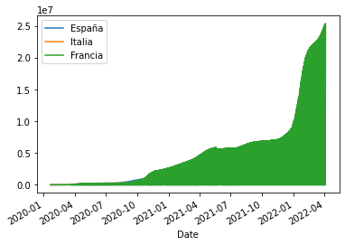

```python
import matplotlib as plt
vs.plot()
plt.savefig('esvsit.png')
```